# Bootstrap confidence intervals when sample size is really small

Jeff Walker

2020-06-01

This is part II of how to represent uncertainty in the mean response of each treatment level. A 1 SE bar, where the SE is computed for each group independently, is nearly universal in much of biology. Part I explains why I prefer confidence intervals to SE bars and explores several alternative methods for computing a CI. One alternative is a non-parametric bootstrap. I like the bootstrap – it is extremely useful for learning and teaching what “frequentist” means. It is not dependent on any distribution. It can be used to compute CIs for statistics where no paramtric CI exists. And its (fairly) easy to implement!

I’ve been using the bootstrap to generate CIs for over 25 years and am embarrassed to admit that I don’t know how well it performs with small samples sizes…on the order of n = 5 or 10, which is really common in bench biology. A problem with small sample size is that any one sample may not be very representative of what the distribution looks like.

This is a small simulation to explore how well a bootstrap performs for estimating CIs of both means and the difference in means. The question pursued is: “do the CIs of a x% bootstrap interval actually cover the mean x% of the time?” The data simulate those in Figure 1F in [β4GALT1 controls β1 integrin function to govern thrombopoiesis and hematopoietic stem cell homeostasis](https://www.nature.com/articles/s41467-019-14178-y).

The data are platelet counts and look they come from a distribution with a strong right skew and variance proportional to the mean (poisson, negative binomial). I approximate the data by sampling from a negative binomial distribution. Then I ask, “does the distribution matter” and re-run the simulation by sampling from a normal distribution with heterogeneity in variance (equal to that in the two groups).

TL;DR – Go to the summary.

```r
knitr::opts_chunk$set(echo = TRUE, message=FALSE)
# wrangling packages
library(here)
library(janitor)
library(readxl)
library(data.table)
library(stringr)

# analysis packages
library(MASS)
library(lmerTest)
library(emmeans)
library(boot)

# graphing packages
library(ggsci)
library(ggpubr)
library(ggforce)
library(cowplot)

here <- here::here()
data_folder <- "content/data"
output_folder <- "content/output"

run_simulation <- FALSE
```

```r
file_folder <- "β4GALT1 controls β1 integrin function to govern thrombopoiesis and hematopoietic stem cell homeostasis"
fn <- "41467_2019_14178_MOESM4_ESM.xlsx"
file_path <- here(data_folder, file_folder, fn)

# Fig 1F
fig1f <- read_excel(file_path,
                    sheet = "Figure 1",
                    range = "I5:J47") %>%
  clean_names()  %>%
  data.table() %>%
  na.omit() # git rid of blank row. there are no NA
fig1f[, treatment := word(x1, 1)]
fig1f[, treatment := factor(treatment, c("Control", "b4GalT1-/-"))]
setnames(fig1f, old="platelets_e14_5", new="platelets")
fig1f[, platelets_orig := round(platelets*10^9)]
```

```r
fig1f_means <- fig1f[, .(platelets = mean(platelets),
                         SD = sd(platelets),
                         SE = sd(platelets/sqrt(.N)),
                         N = .N)
                     , by = treatment]
fig1f_means[, lower := platelets + SE*qt(.025, (N-1))]
fig1f_means[, upper := platelets + SE*qt(.975, (N-1))]

set.seed(1)
gg_points <- ggplot(data = fig1f,
                 aes(x = treatment, y = platelets)) +
  geom_sina(alpha=0.4) +
  theme_pubr() +
  NULL

set.seed(1)
gg_raw <- gg_points +
  geom_point(data = fig1f_means,
             aes(y = platelets),
             size = 3,
             color = c("#3DB7E9", "#e69f00")) +
  geom_errorbar(data = fig1f_means,
                aes(ymin = lower, ymax = upper),
                width = 0.04,
                size = 1,
                color = c("#3DB7E9", "#e69f00")) +
  NULL

#gg_raw
```

# A bootstrap function

This function returns two sets of CIs for the 1) modeled means of the observed fit and the 2) parameters of the observed fit. The first set is from a residual bootstrap. This seems weird because if there is heterogeneity, then a residual bootstrap spreads this heterogeneity among all groups. The second is from a stratified bootstrap.

```r
# # # # # # # # #
# This function returns two sets of CIs for the 1) modeld means of the observed fit
# and the 2) parameters of the observed fit. The first set is from a residual bootstrap.
# This seems weird because if there is heterogeneity, then a residual bootstrap spreads
# this heterogeneity among all groups. The second is from a stratified bootstrap
# # # # # # # # #
boot_lm_test <- function(obs_fit,
                         n_boot = 1000,
                         ci = 0.95,
                         method = "stratified"){
  ci_lo <- (1-ci)/2
  ci_hi <- 1 - (1-ci)/2
  boot_dt <- data.table(obs_fit$model)
  boot_dt[, id:=.I]
  x_label <- names(obs_fit$xlevels)[1]
  group_first_row <- boot_dt[, .(bfr = min(id)), by=get(x_label)][,bfr]

  obs_beta <- coef(obs_fit)
  obs_error <- residuals(obs_fit)
  obs_yhat <- fitted(obs_fit)
  obs_y <- obs_fit$model[,1]
  obs_x <- obs_fit$model[,2]
  X <- model.matrix(obs_fit)
  xtxixt <- solve(t(X)%*%X)%*%t(X)
  N <- nrow(obs_fit$model)
  inc_resid <- 1:N
  inc_strat <- 1:N
  beta_resid <- matrix(NA, nrow=n_boot, ncol=length(obs_beta))
  beta_strat <- matrix(NA, nrow=n_boot, ncol=length(obs_beta))
  mu_resid <- matrix(NA, nrow=n_boot, ncol=length(obs_beta))
  mu_strat <- matrix(NA, nrow=n_boot, ncol=length(obs_beta))
  for(iter in 1:n_boot){

    # y_resamp_residuals <- obs_yhat + obs_error[inc_resid]
    # beta_resid[iter,] <- (xtxixt%*%y_resamp_residuals)[,1]
    # mu_resid[iter, ] <- (X%*%beta_resid[iter,])[group_first_row, 1]

    y_resamp_strat <- obs_y[inc_strat]
    beta_strat[iter,] <- (xtxixt%*%y_resamp_strat)[,1]
    mu_strat[iter, ] <- (X%*%beta_strat[iter,])[group_first_row, 1]

    inc_resid <- sample(1:N, replace = TRUE)
    inc_strat <- with(boot_dt, ave(id, get(x_label), FUN=function(x) {sample(x, replace=TRUE)}))
  }

  # ci_resid_beta <- apply(beta_resid, 2, quantile, c(ci_lo, ci_hi))
  # ci_resid_mu <- apply(mu_resid, 2, quantile, c(ci_lo, ci_hi))
  ci_strat_mu <- apply(mu_strat, 2, quantile, c(ci_lo, ci_hi))
  ci_strat_beta <- apply(beta_strat, 2, quantile, c(ci_lo, ci_hi))

  return(list(
    # ci_resid_beta = ci_resid_beta,
    # ci_resid_mu = ci_resid_mu,
    ci_strat_beta = ci_strat_beta,
    ci_strat_mu = ci_strat_mu
  ))
}
```

# Bootstrap CIs

```r
m1 <- lm(platelets ~ treatment, data = fig1f)
m1_boot <- boot_lm_test(m1)

fig1f_means[, lower.boot := m1_boot$ci_strat_mu["2.5%",]]
fig1f_means[, upper.boot := m1_boot$ci_strat_mu["97.5%",]]

set.seed(1)
gg_boot <- gg_points +
  geom_point(data = fig1f_means,
             aes(y = platelets),
             size = 3,
             color = c("#3DB7E9", "#e69f00")) +
  geom_errorbar(data = fig1f_means,
                aes(ymin = lower.boot, ymax = upper.boot),
                width = 0.04,
                size = 1,
                color = c("#3DB7E9", "#e69f00")) +
  NULL

#gg_boot
```

# plot of data, raw CIs, bootstrap CIs

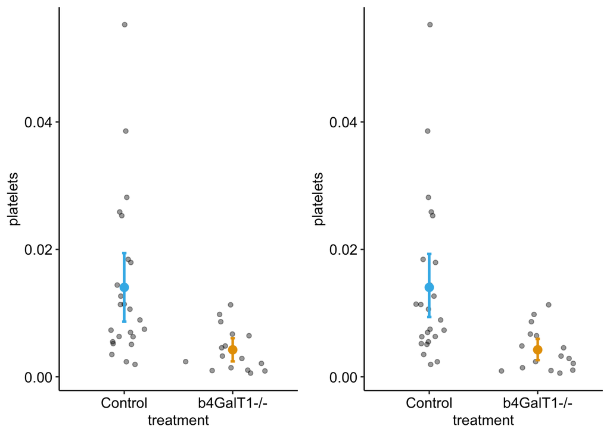

```r
plot_grid(gg_raw, gg_boot, ncol=2)
```

Not a big difference.

# Simulation

```r
boot_sim <- function(
  mu, # mean of each level
  model = "nb", # distribution of the data, normal or nb
  theta = 1, #theta for nb
  sigma = 1, # sd of each level for normal
  beta, # coefficients of model
  n_sim = 1000, # iterations of simulation
  n_boot = 1000, # number of bootstrap resamples
  n_list = 30, # vector of sample sizes per level. Whole sim run for each n
  method = "stratified" # stratified, residual, or both
){
  k <- length(mu)
  treatment_levels <- c("cn", paste0("tr", 1:(k-1)))

  coverage_table_mu <- data.table(group = names(mu))
  coverage_table_beta <- data.table(parameter = names(beta))


  for(n in n_list){
    N <- k*n
    # vector of parameters for sampling function
    sim_mu <- rep(mu, each=n)
    sim_sigma <- rep(sigma, each=n)

    fd <- data.table(
      treatment = rep(treatment_levels, each=n)
    )

    boot_ci_strat_mu<- matrix(FALSE, nrow = n_sim, ncol=k)
    boot_ci_strat_beta <- matrix(FALSE, nrow = n_sim, ncol=k)

    for(iter in 1:n_sim){
      if(model=="nb"){
        fd[, y_fake := rnegbin(N, sim_mu, theta)]
      }
      if(model=="normal"){
        fd[, y_fake := rnorm(N, sim_mu, sim_sigma)]
      }

      fit_fake <- lm(y_fake ~ treatment, data=fd)
      ci_list <- boot_lm_test(fit_fake,
                              n_boot = n_boot,
                              ci=0.95,
                              method = method)
      ci_strat_i_mu <- ci_list$ci_strat_mu
      ci_strat_i_beta <- ci_list$ci_strat_beta

      boot_ci_strat_beta[iter,] <- beta > ci_strat_i_beta[1,] &
        beta < ci_strat_i_beta[2,]
      boot_ci_strat_mu[iter,] <- mu > ci_strat_i_mu[1,] &
        mu < ci_strat_i_mu[2,]
    }
    coverage_table_mu <- cbind(coverage_table_mu,
                               x = apply(boot_ci_strat_mu, 2, sum)/n_sim*100)
    setnames(coverage_table_mu, "x", paste0("n=", n))

    coverage_table_beta <- cbind(coverage_table_beta,
                                 x = apply(boot_ci_strat_beta, 2, sum)/n_sim*100)
    setnames(coverage_table_beta, "x", paste0("n=", n))
  }

  return(list(
    coverage_table_mu = coverage_table_mu,
    coverage_table_beta = coverage_table_beta
    )
  )
}
```

```r
# # # # # # # # #
# This script explores "do the CIs of a x% bootstrap interval actually cover the mean x%
# of the time". The sample is from a negative binomial distribution so there is
# heterogeneity of variance.
# # # # # # # # #

set.seed(1)
n_sim <- 2000
n_boot <- 1000
n_list <- c(5, 10, 20, 40, 80)

lm_obs <- lm(platelets_orig ~ treatment, data = fig1f)
lm_obs_sigma <- summary(lm_obs)$sigma
glm_obs <- glm.nb(platelets_orig ~ treatment, data = fig1f)
glm_obs_fitted <- glm_obs$fitted.values
glm_obs_theta  <- glm_obs$theta

mu_levels <- summary(emmeans(lm_obs, specs = "treatment"))[, "emmean"]
names(mu_levels) <- summary(emmeans(lm_obs, specs = "treatment"))[, "treatment"]
beta <- coef(lm_obs)
theta <- glm_obs_theta
sigma_raw <- fig1f_means[, SD]
names(sigma_raw) <- fig1f_means[, treatment]
```

```r
out_file <- "boot_ci-nb.Rds"
save_file_path <- here(output_folder, out_file)

if(run_simulation == TRUE){
  boot_ci_sim_nb <- boot_sim(
    mu = mu_levels, # mean of each level
    model = "nb", # distribution of the data, normal or nb
    theta = theta, #theta for nb
    sigma = sigma_raw, # sd of each level for normal
    beta = beta, # coefficients
    n_sim = n_sim, # iterations of simulation
    n_boot = n_boot, # number of bootstrap resamples
    n_list = n_list, # vector of sample sizes per level. Whole sim run for each n
    method = "stratified" # stratified, residual, or both
  )
  saveRDS(object = boot_ci_sim_nb, file = save_file_path)
}else{
  boot_ci_sim_nb <- readRDS(save_file_path)
}

boot_ci_sim_nb$coverage_table_mu
```

```
##         group  n=5  n=10 n=20 n=40  n=80
## 1:    Control 80.6 86.15 90.4 92.2 94.20
## 2: b4GalT1-/- 79.4 87.10 91.0 92.3 93.55
```

```r
boot_ci_sim_nb$coverage_table_beta
```

```
##              parameter   n=5  n=10 n=20  n=40  n=80
## 1:         (Intercept) 80.60 86.15 90.4 92.20 94.20
## 2: treatmentb4GalT1-/- 82.85 87.60 91.2 92.65 93.65
```

```r
out_file <- "boot_ci-normal.Rds"
save_file_path <- here(output_folder, out_file)

if(run_simulation == TRUE){
  boot_ci_sim_normal <- boot_sim(
    mu = mu_levels, # mean of each level
    model = "normal", # distribution of the data, normal or nb
    theta = theta, #theta for nb
    sigma = sigma_raw, # sd of each level for normal
    beta = beta, # coefficients
    n_sim = n_sim, # iterations of simulation
    n_boot = n_boot, # number of bootstrap resamples
    n_list = n_list, # vector of sample sizes per level. Whole sim run for each n
    method = "stratified" # stratified, residual, or both
  )
  saveRDS(object = boot_ci_sim_normal, file = save_file_path)
}else{
  boot_ci_sim_normal <- readRDS(save_file_path)
}

boot_ci_sim_normal$coverage_table_mu
```

```
##         group   n=5  n=10  n=20 n=40  n=80
## 1:    Control 83.55 89.20 92.65 94.3 94.80
## 2: b4GalT1-/- 84.50 89.95 92.40 93.9 95.85
```

```r
boot_ci_sim_normal$coverage_table_beta
```

```
##              parameter   n=5  n=10  n=20  n=40 n=80
## 1:         (Intercept) 83.55 89.20 92.65 94.30 94.8
## 2: treatmentb4GalT1-/- 84.65 89.65 92.85 94.05 95.2
```

# Summary

## group means, sampled from negative binomial

Coverage of the estimate of the mean, for data sampled from a negative binomial distribution

| group | n=5 | n=10 | n=20 | n=40 | n=80 |
| --- | --- | --- | --- | --- | --- |
| Control | 80.6 | 86.15 | 90.4 | 92.2 | 94.20 |
| b4GalT1-/- | 79.4 | 87.10 | 91.0 | 92.3 | 93.55 |

## coefficients, sampled from negative binomial

Coverage of the estimate of the difference in means, for data sampled from a negative binomial distribution

| parameter | n=5 | n=10 | n=20 | n=40 | n=80 |
| --- | --- | --- | --- | --- | --- |
| (Intercept) | 80.60 | 86.15 | 90.4 | 92.20 | 94.20 |
| treatmentb4GalT1-/- | 82.85 | 87.60 | 91.2 | 92.65 | 93.65 |

## group means, sampled from normal

Coverage of the estimate of the mean, for data sampled from normal distribution

| group | n=5 | n=10 | n=20 | n=40 | n=80 |
| --- | --- | --- | --- | --- | --- |
| Control | 83.55 | 89.20 | 92.65 | 94.3 | 94.80 |
| b4GalT1-/- | 84.50 | 89.95 | 92.40 | 93.9 | 95.85 |

## coefficients, sampled from normal

Coverage of the estimate of the difference in means, for data sampled from a normal distribution

| parameter | n=5 | n=10 | n=20 | n=40 | n=80 |
| --- | --- | --- | --- | --- | --- |
| (Intercept) | 83.55 | 89.20 | 92.65 | 94.30 | 94.8 |
| treatmentb4GalT1-/- | 84.65 | 89.65 | 92.85 | 94.05 | 95.2 |

Huh. The bootstrap intervals are very…optimistic at sample sizes typical of bench biology. Yes, books on the bootstrap do cover small sample issues and potential solutions. But I’m surprised by how little I’ve seen references to this, or maybe I’ve just selectively filtered it out.